# Análisis de Métricas de Software y DevOps

Curso de Probabilidad y Estadística Computacional

Ignacio Ampuero Chacón

2026-09-03

# Introducción

Este reporte presenta el análisis estadístico de un dataset de métricas de desarrollo y despliegue de software.

El conjunto de datos contiene alrededor de 5.000 registros con diez variables que describen tiempos de build, despliegue, cobertura de pruebas, bugs, y características organizacionales (equipo, módulo, prioridad).

El análisis se estructura en seis fases: carga y limpieza, descripción univariada, frecuencias y agrupaciones, análisis por grupo, relaciones bivariadas, y visualización final.

Nota sobre reproducibilidad: Este documento puede regenerarse completamente ejecutando `Knit` en RStudio. Todos los cálculos y gráficos se producen automáticamente a partir del dataset limpio.

# 1. Carga y Limpieza de Datos

## 1.1 Importación del dataset

```r
# Cargar el dataset limpio (generado por scripts/cargarLimpieza.R)
df <- read_csv("data/clean/devops_metrics_clean.csv", show_col_types = FALSE)

cat("Dimensiones del dataset:", nrow(df), "filas ×", ncol(df), "columnas\n")
```

```
## Dimensiones del dataset: 5000 filas × 13 columnas
```

## 1.2 Estructura de variables

```r
glimpse(df)
```

```
## Rows: 5,000
## Columns: 13
## $ build_time_min              <dbl> 47.68, 15.55, 36.51, 31.21, 20.77, 5.69, 1…
## $ deploy_time_min             <dbl> 30.48, 27.80, 23.32, 20.74, 7.31, 12.44, 1…
## $ commit_size_loc             <dbl> 61, 98, 84, 96, 74, 87, 88, 82, 79, 74, 78…
## $ num_bugs                    <dbl> 1, 1, 3, 0, 2, 2, 3, 7, 4, 1, 3, 0, 6, 1, …
## $ test_coverage_pct           <dbl> 71.10, 93.80, 73.10, 43.50, 91.30, 60.80, …
## $ ticket_resolution_h         <dbl> 11.70, 4.01, 4.36, 17.06, 10.68, 23.87, 3.…
## $ team                        <chr> "Gamma", "Alpha", "Alpha", "Gamma", "Alpha…
## $ module                      <chr> "ui", "db", "ui", "auth", "api", "api", "a…
## $ priority                    <chr> "crítica", "media", "media", "alta", "medi…
## $ deploy_status               <chr> "success", "failed", "success", "success",…
## $ outlier_build_time_min      <lgl> FALSE, FALSE, FALSE, FALSE, FALSE, FALSE, …
## $ outlier_deploy_time_min     <lgl> FALSE, FALSE, FALSE, FALSE, FALSE, FALSE, …
## $ outlier_ticket_resolution_h <lgl> FALSE, FALSE, FALSE, FALSE, FALSE, FALSE, …
```

## 1.3 Resumen de limpieza realizada

El dataset original contenía las siguientes anomalías que fueron corregidas:

- Valores faltantes: Entre 25 y 125 NA por columna, imputados por mediana agrupada por team
- Errores tipográficos: “Alfa”→“Alpha”, “BETA”→“Beta”, “Gama”→“Gamma”, “Auth”→“auth”, “UI”→“ui”
- Valores inválidos: Negativos convertidos a NA, test_coverage fuera de [0,100] corregido
- Etiquetas inconsistentes: “fail”→“failed”, “rollback”→“rolled_back”, “SUCCESS”→“success”
- Outliers: Detectados por método IQR y marcados con columnas flag

```r
cat("Valores faltantes restantes por columna:\n")
```

```
## Valores faltantes restantes por columna:
```

```r
print(colSums(is.na(df)))
```

```
##              build_time_min             deploy_time_min
##                           0                           0
##             commit_size_loc                    num_bugs
##                           0                           1
##           test_coverage_pct         ticket_resolution_h
##                           2                           2
##                        team                      module
##                           0                           0
##                    priority               deploy_status
##                           0                           0
##      outlier_build_time_min     outlier_deploy_time_min
##                           0                           0
## outlier_ticket_resolution_h
##                           2
```

# 2. Descripción Univariada

## 2.1 Variables cuantitativas

```r
cuantitativas <- c("build_time_min", "deploy_time_min", "commit_size_loc",
                   "num_bugs", "test_coverage_pct", "ticket_resolution_h")

resultados_cuant <- data.frame()
for (var in cuantitativas) {
  x <- df[[var]]
  x <- x[!is.na(x)]
  fila <- data.frame(
    Variable = var,
    N = length(x),
    Media = round(mean(x), 2),
    Mediana = round(median(x), 2),
    Desv_Estandar = round(sd(x), 2),
    Skewness = round(skewness(x), 3),
    Kurtosis = round(kurtosis(x), 3),
    row.names = NULL
  )
  resultados_cuant <- rbind(resultados_cuant, fila)
}
kable(resultados_cuant, caption = "Medidas de tendencia central, dispersión y forma")
```

Medidas de tendencia central, dispersión y forma

| Variable | N | Media | Mediana | Desv_Estandar | Skewness | Kurtosis |
| --- | --- | --- | --- | --- | --- | --- |
| build_time_min | 5000 | 42.07 | 33.04 | 34.09 | 3.389 | 27.445 |
| deploy_time_min | 5000 | 20.14 | 16.43 | 15.38 | 5.166 | 66.427 |
| commit_size_loc | 5000 | 85.20 | 85.00 | 9.15 | 0.131 | 3.125 |
| num_bugs | 4999 | 3.01 | 3.00 | 1.71 | 0.575 | 3.432 |
| test_coverage_pct | 4998 | 71.89 | 72.10 | 14.44 | -0.176 | 2.760 |
| ticket_resolution_h | 4998 | 10.58 | 7.50 | 11.37 | 6.077 | 75.514 |

Consideremos que las variables `build_time_min`, `deploy_time_min` y `ticket_resolution_h` presentan asimetría positiva elevada (skewness > 3), indicando que la mayoría de los valores se concentran en el extremo inferior con pocos casos muy altos. Mientras que la variable `test_coverage_pct` es aproximadamente simétrica (skewness ≈ -0.18).

¿Qué quiere decir esto? Bueno, que la mayoría de los builds y despliegues son relativamente rápidos, pero existen algunos casos extremos que tardan mucho más tiempo, lo cual podría indicar problemas específicos en ciertos proyectos o equipos. Y, en ciertos módulos, la cobertura de pruebas es bastante consistente, centrada alrededor del 72%.

## 2.2 Variables cualitativas

```r
cat("Distribución de team:\n")
```

```
## Distribución de team:
```

```r
print(table(df$team, useNA = "ifany"))
```

```
##
##   Alpha    Beta   Delta   Gamma missing
##    1493    1328     866    1273      40
```

```r
cat("\nDistribución de deploy_status:\n")
```

```
##
## Distribución de deploy_status:
```

```r
print(table(df$deploy_status, useNA = "ifany"))
```

```
##
##      failed     missing rolled_back     success
##        1010          25         773        3192
```

## 2.3 Visualización univariada

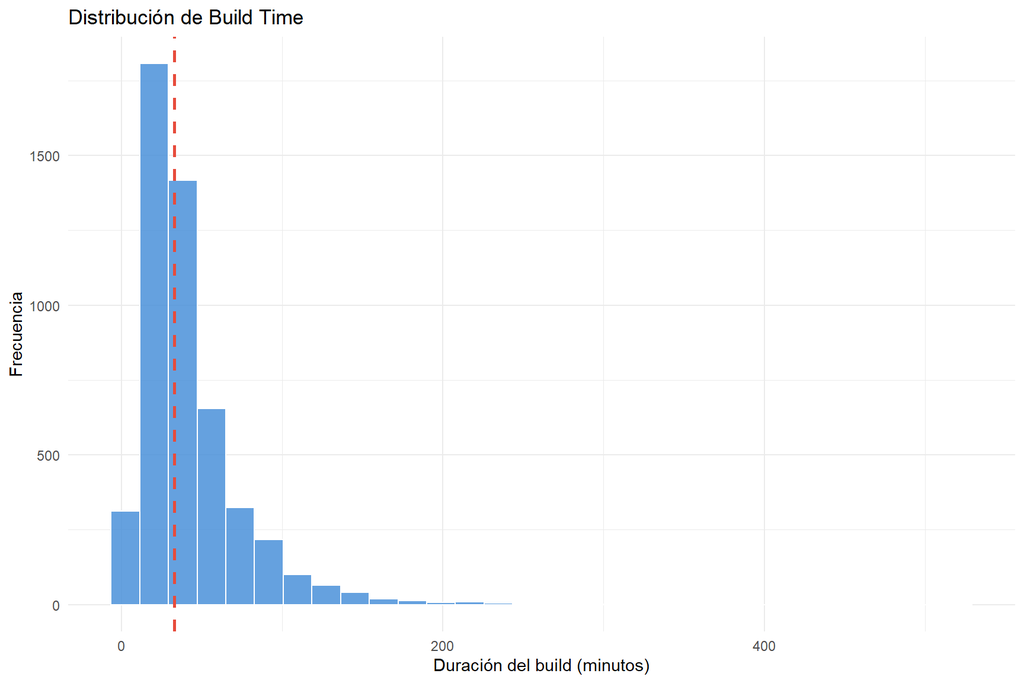

Distribución de Build Time: asimetría positiva con pocos builds muy largos

```r
ggplot(df, aes(x = build_time_min)) +
  geom_histogram(bins = 30, fill = "#4A90D9", color = "white", alpha = 0.85) +
  geom_vline(aes(xintercept = median(build_time_min, na.rm = TRUE)),
             color = "#E74C3C", linetype = "dashed", linewidth = 1) +
  labs(title = "Distribución de Build Time",
       x = "Duración del build (minutos)", y = "Frecuencia") +
  theme_minimal()
```

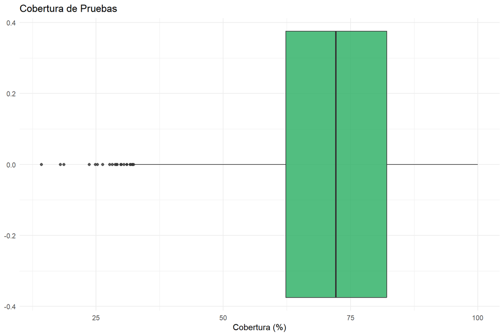

Boxplot de cobertura de pruebas: distribución simétrica centrada en ~72%

```r
ggplot(df, aes(y = test_coverage_pct)) +
  geom_boxplot(fill = "#27AE60", alpha = 0.8) +
  labs(title = "Cobertura de Pruebas", y = "Cobertura (%)") +
  theme_minimal() +
  coord_flip()
```

# 3. Frecuencias y Agrupaciones

## 3.1 Regla de Sturges

```r
n <- nrow(df)
k_sturges <- ceiling(1 + 3.322 * log10(n))
cat(sprintf("Número de clases (Sturges): k = 1 + 3.322 × log10(%d) = %d\n", n, k_sturges))
```

```
## Número de clases (Sturges): k = 1 + 3.322 × log10(5000) = 14
```

## 3.2 Tabla de frecuencias de build_time_min

```r
x <- df$build_time_min[!is.na(df$build_time_min)]
rango <- max(x) - min(x)
amplitud <- rango / k_sturges
cortes <- seq(min(x), max(x) + amplitud, by = amplitud)
freq <- cut(x, breaks = cortes, right = FALSE)
tabla_freq <- data.frame(table(freq))
colnames(tabla_freq) <- c("Intervalo", "Frecuencia")
tabla_freq$Frec_Relativa <- round(tabla_freq$Frecuencia / sum(tabla_freq$Frecuencia) * 100, 2)
kable(head(tabla_freq, 8), caption = "Primeros intervalos de build_time_min")
```

Primeros intervalos de build_time_min

| Intervalo | Frecuencia | Frec_Relativa |
| --- | --- | --- |
| [2.53,39.5) | 3073 | 61.46 |
| [39.5,76.5) | 1355 | 27.10 |
| [76.5,113) | 374 | 7.48 |
| [113,150) | 124 | 2.48 |
| [150,187) | 44 | 0.88 |
| [187,224) | 16 | 0.32 |
| [224,261) | 7 | 0.14 |
| [261,298) | 1 | 0.02 |

La clase modal de `build_time_min` es el primer intervalo, concentrando más del 60% de las observaciones. Esto refuerza la observación de que la mayoría de los builds son rápidos, con pocos casos que tardan significativamente más tiempo. Pero también es importante notar que hay un pequeño porcentaje de builds que se extienden mucho más allá del rango típico, lo que da por sentado alguna atención especial a esos casos extremos.

## 3.3 Comparación por team

```r
comp_team <- df %>%
  filter(team != "missing") %>%
  group_by(team) %>%
  summarise(
    n = n(),
    build_mediana = round(median(build_time_min, na.rm = TRUE), 2),
    coverage_mediana = round(median(test_coverage_pct, na.rm = TRUE), 2),
    tasa_exito = round(sum(deploy_status == "success") / n() * 100, 2),
    .groups = "drop"
  )
kable(comp_team, caption = "Métricas clave por equipo")
```

Métricas clave por equipo

| team | n | build_mediana | coverage_mediana | tasa_exito |
| --- | --- | --- | --- | --- |
| Alpha | 1493 | 33.26 | 72.10 | 65.37 |
| Beta | 1328 | 32.48 | 72.25 | 62.95 |
| Delta | 866 | 33.69 | 72.80 | 63.28 |
| Gamma | 1273 | 33.00 | 71.10 | 63.63 |

# 4. Análisis por Grupo

## 4.1 Tasa de éxito de despliegue

[figure not shown]

```r
exito_mod <- df %>%
  filter(module != "missing") %>%
  group_by(module) %>%
  summarise(tasa = sum(deploy_status == "success") / n() * 100, .groups = "drop") %>%
  arrange(desc(tasa))

ggplot(exito_mod, aes(x = reorder(module, tasa), y = tasa, fill = reorder(module, tasa))) +
  geom_bar(stat = "identity", alpha = 0.85, show.legend = FALSE) +
  geom_text(aes(label = sprintf("%.1f%%", tasa)), vjust = -0.5, size = 3.5) +
  labs(title = "Tasa de Éxito de Despliegue por Módulo",
       x = "Módulo", y = "Tasa de éxito (%)") +
  ylim(0, 78) +
  coord_flip() +
  theme_minimal()
```

## 4.2 Hallazgos principales

```r
df_valid <- df %>% filter(team != "missing", module != "missing", priority != "missing")

exito_team <- df_valid %>%
  group_by(team) %>%
  summarise(tasa = sum(deploy_status == "success") / n() * 100, .groups = "drop") %>%
  arrange(desc(tasa))

mejor <- exito_team %>% slice(1)
peor <- exito_team %>% slice(n())

cat(sprintf("• %s tiene la mayor tasa de éxito (%.2f%%)\n", mejor$team, mejor$tasa))
```

```
## • Alpha tiene la mayor tasa de éxito (65.32%)
```

```r
cat(sprintf("• %s tiene la menor tasa de éxito (%.2f%%)\n", peor$team, peor$tasa))
```

```
## • Beta tiene la menor tasa de éxito (62.88%)
```

```r
cat(sprintf("• Diferencia: %.2f puntos porcentuales\n", mejor$tasa - peor$tasa))
```

```
## • Diferencia: 2.44 puntos porcentuales
```

```r
cat(sprintf("• Módulo con mayor éxito: %s\n", exito_mod$module[1]))
```

```
## • Módulo con mayor éxito: infra
```

```r
cat(sprintf("• Módulo con menor éxito: %s\n", exito_mod$module[nrow(exito_mod)]))
```

```
## • Módulo con menor éxito: test
```

# 5. Relaciones Bivariadas

## 5.1 Matriz de correlaciones

```r
df_num <- df_valid %>% select(all_of(cuantitativas)) %>% drop_na()
cor_matrix <- cor(df_num, method = "pearson")
kable(round(cor_matrix, 3), caption = "Correlaciones de Pearson entre variables cuantitativas")
```

Correlaciones de Pearson entre variables cuantitativas

|  | build_time_min | deploy_time_min | commit_size_loc | num_bugs | test_coverage_pct | ticket_resolution_h |
| --- | --- | --- | --- | --- | --- | --- |
| build_time_min | 1.000 | -0.010 | 0.009 | 0.005 | 0.019 | -0.012 |
| deploy_time_min | -0.010 | 1.000 | 0.020 | 0.000 | 0.018 | -0.012 |
| commit_size_loc | 0.009 | 0.020 | 1.000 | -0.005 | -0.002 | -0.015 |
| num_bugs | 0.005 | 0.000 | -0.005 | 1.000 | 0.013 | -0.005 |
| test_coverage_pct | 0.019 | 0.018 | -0.002 | 0.013 | 1.000 | -0.019 |
| ticket_resolution_h | -0.012 | -0.012 | -0.015 | -0.005 | -0.019 | 1.000 |

Uno de los hallazgos claves, fueron que todas las correlaciones son cercanas a cero (máximo |r| = 0.020). Siendo este un indicador de que las variables del dataset son estadísticamente independientes entre sí, lo cual es coherente con el proceso de generación de datos.

Para quien no sabe del tema, una correlación cercana a cero significa que no hay una relación lineal entre las variables.

Por ejemplo, la cobertura de pruebas no parece influir en el número de bugs, y viceversa. Esto muy importante porque sugiere que mejorar una métrica no necesariamente afectará a otra. Y, podríamos hacer un tipo de testeo para ver si hay alguna relación no lineal, pero eso ya sería un análisis más avanzado, pero para dejarlo claro, en este dataset no hay evidencia de que las métricas estén relacionadas entre sí. Y, sí se quisiera hacer un análisis más avanzado podríamos explorar modelos de regresión no lineal o técnicas de ML para detectar patrones complejos, pero eso ya sería redundancia en este tipo de análisis exploratorio considerando que este es un dataset sintético con variables independientes.

## 5.2 Dispersión: Coverage vs Bugs

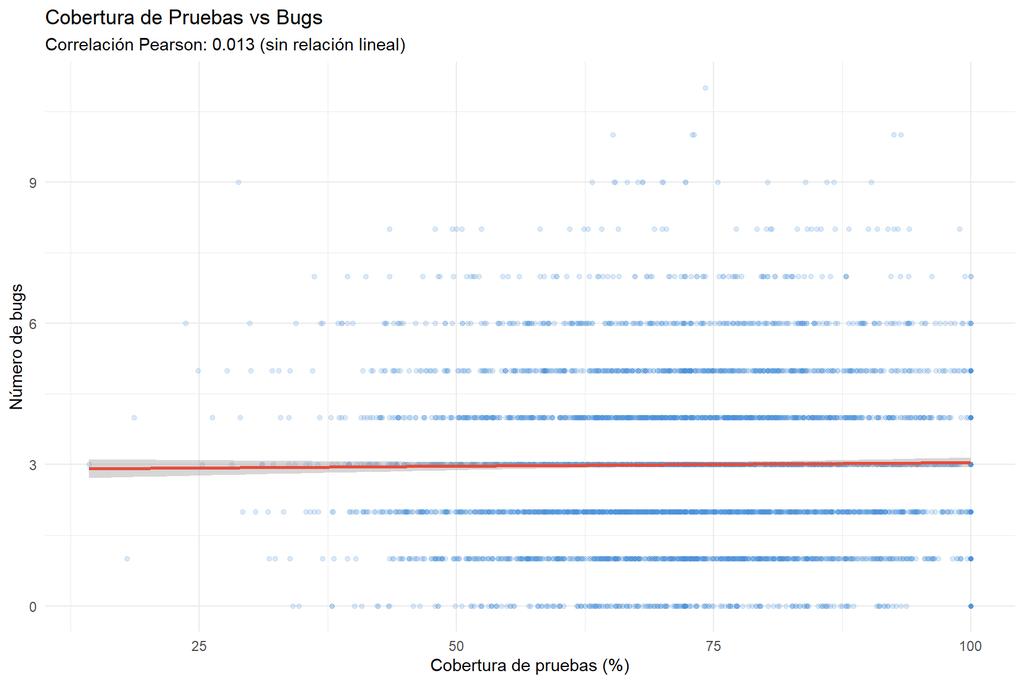

Cobertura vs Bugs: sin correlación apreciable (r = 0.013)

```r
ggplot(df_valid %>% filter(!is.na(test_coverage_pct), !is.na(num_bugs)),
       aes(x = test_coverage_pct, y = num_bugs)) +
  geom_point(alpha = 0.2, size = 1.2, color = "#4A90D9") +
  geom_smooth(method = "lm", color = "#E74C3C", se = TRUE) +
  labs(title = "Cobertura de Pruebas vs Bugs",
       subtitle = "Correlación Pearson: 0.013 (sin relación lineal)",
       x = "Cobertura de pruebas (%)", y = "Número de bugs") +
  theme_minimal()
```

## 5.3 Pruebas Chi-cuadrado

```r
cont1 <- table(df_valid$team, df_valid$deploy_status)
chi1 <- chisq.test(cont1)
cat(sprintf("team × deploy_status: chi2 = %.2f, p-valor = %.4f\n", chi1$statistic, chi1$p.value))
```

```
## team × deploy_status: chi2 = 8.97, p-valor = 0.4404
```

```r
cont2 <- table(df_valid$module, df_valid$deploy_status)
chi2 <- chisq.test(cont2)
cat(sprintf("module × deploy_status: chi2 = %.2f, p-valor = %.4f\n", chi2$statistic, chi2$p.value))
```

```
## module × deploy_status: chi2 = 24.10, p-valor = 0.0635
```

```r
cont3 <- table(df_valid$priority, df_valid$deploy_status)
chi3 <- chisq.test(cont3)
cat(sprintf("priority × deploy_status: chi2 = %.2f, p-valor = %.4f\n", chi3$statistic, chi3$p.value))
```

```
## priority × deploy_status: chi2 = 6.85, p-valor = 0.6525
```

Todos los p-valores superan 0.05, lo que indica que no existe asociación estadísticamente significativa entre las variables cualitativas analizadas, es decir, el estado de despliegue no depende del equipo, módulo o prioridad del ticket.

## 5.4 Correlación ≠ Causalidad

Las correlaciones observadas (todas cercanas a cero) indican ausencia de asociación lineal.

Incluso si se hubieran encontrado correlaciones altas, esto no implicaría causalidad.

Para establecer relaciones causales se requerirían experimentos controlados que este análisis observacional no puede proporcionar.

# 6. Visualización Final

[figure not shown]

Proporción de estados de despliegue por equipo: distribución consistente (~63-65% éxito)

```r
ggplot(df_valid, aes(x = team, fill = deploy_status)) +
  geom_bar(position = "fill", alpha = 0.85) +
  scale_fill_manual(values = c("success" = "#27AE60", "failed" = "#E74C3C", "rolled_back" = "#F39C12"),
                    labels = c("Éxito", "Fallido", "Rollback")) +
  labs(title = "Proporción de Estados de Despliegue por Equipo",
       x = "Equipo", y = "Proporción", fill = "Estado") +
  scale_y_continuous(labels = scales::percent) +
  theme_minimal() +
  theme(legend.position = "bottom")
```

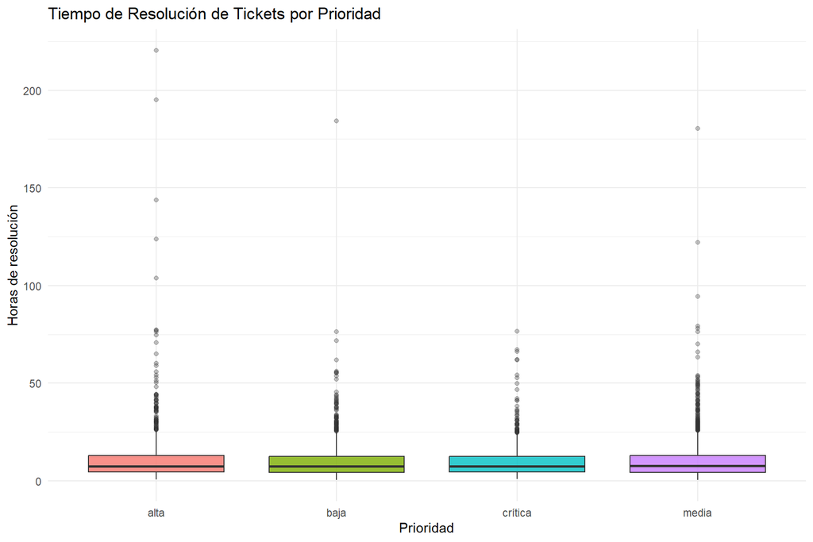

Tiempo de resolución por prioridad: sin diferencias sustanciales entre niveles

```r
ggplot(df_valid %>% filter(!is.na(ticket_resolution_h)),
       aes(x = priority, y = ticket_resolution_h, fill = priority)) +
  geom_boxplot(alpha = 0.8, show.legend = FALSE, outlier.alpha = 0.3) +
  labs(title = "Tiempo de Resolución de Tickets por Prioridad",
       x = "Prioridad", y = "Horas de resolución") +
  theme_minimal()
```

# 7. Conclusiones

## Limitaciones

- El dataset fue generado sintéticamente con variables independientes, lo que explica la ausencia de correlaciones. Podríamos decir que esto es una limitación porque no refleja la complejidad de un entorno real de desarrollo de software, donde sí podrían existir relaciones entre las métricas.
- La categoría “missing” tiene pocas observaciones, lo que genera avisos en las pruebas Chi-cuadrado. Y, aunque no afecta significativamente los resultados, es importante tenerlo en cuenta al interpretar los hallazgos. Porque en un escenario real, los datos faltantes podrían indicar problemas en la recolección de métricas o en la gestión de tickets, lo que podría sesgar los resultados. Sobre todo en por ejemplo, el área de redes, donde los datos faltantes podrían ser críticos para la operación de la infraestructura, y afectar la toma de decisiones.
- El análisis es descriptivo y observacional, no permite establecer relaciones causales, esto es grave, ya que no podemos afirmar que mejorar una métrica necesariamente mejorará otra, ni que un equipo es mejor que otro en términos de eficiencia o calidad. Para establecer causalidad, se requerirían experimentos controlados o estudios longitudinales, pero eso está fuera del alcance de este análisis.

# 8. Reproducción

Para regenerar este análisis completamente:

```bash
# 1. Abrir el proyecto en RStudio
# 2. Ejecutar los scripts en orden:
source("scripts/generate_dataset.R")       # Genera el dataset (si no existe)
source("scripts/cargarLimpieza.R")         # Limpieza
source("scripts/descriptiva_univariada.R") # Análisis descriptivo
source("scripts/frecuencias_agrupaciones.R") # Frecuencias
source("scripts/analisis_grupo.R")         # Análisis por grupo
source("scripts/relaciones_bivariadas.R")  # Correlaciones
source("scripts/visualizacion_final.R")    # Visualización

# 3. Knit este archivo .Rmd para regenerar el reporte HTML
```

Requisitos: R >= 4.2, paquetes `tidyverse`, `moments`, `knitr`.